# Unsupervised Learning

## Exploring text datasets

```r
# reading data and computing additional variables
library(readtext)
library(quanteda)
library(quanteda.corpora)


# saveing corpus object from quanteda.corpora
data_corpus_SOTU<-data_corpus_sotu
summary(data_corpus_SOTU)
```

```
## Corpus consisting of 239 documents, showing 100 documents:
##
##              Text Types Tokens Sentences     FirstName  President
##   Washington-1790   460   1167        24        George Washington
##  Washington-1790b   591   1501        38        George Washington
##   Washington-1791   814   2471        58        George Washington
##   Washington-1792   769   2282        59        George Washington
##   Washington-1793   800   2116        54        George Washington
##   Washington-1794  1134   3192        77        George Washington
##   Washington-1795   819   2149        51        George Washington
##   Washington-1796  1003   3090        76        George Washington
##        Adams-1797   731   2230        58          John      Adams
##        Adams-1798   833   2368        54          John      Adams
##        Adams-1799   597   1624        35          John      Adams
##        Adams-1800   562   1489        40          John      Adams
##    Jefferson-1801  1098   3493        90        Thomas  Jefferson
##    Jefferson-1802   821   2392        60        Thomas  Jefferson
##    Jefferson-1803   835   2460        46        Thomas  Jefferson
##    Jefferson-1804   743   2281        48        Thomas  Jefferson
##    Jefferson-1805   982   3168        76        Thomas  Jefferson
##    Jefferson-1806   966   3108        74        Thomas  Jefferson
##    Jefferson-1807   856   2603        60        Thomas  Jefferson
##    Jefferson-1808   954   2916        70        Thomas  Jefferson
##      Madison-1809   699   1950        40         James    Madison
##      Madison-1810   893   2615        61         James    Madison
##      Madison-1811   829   2439        46         James    Madison
##      Madison-1812  1126   3493        87         James    Madison
##      Madison-1813  1074   3521        67         James    Madison
##      Madison-1814   831   2282        50         James    Madison
##      Madison-1815  1050   3387        59         James    Madison
##      Madison-1816  1086   3614        72         James    Madison
##       Monroe-1817  1221   4812       122         James     Monroe
##       Monroe-1818  1243   4726       114         James     Monroe
##       Monroe-1819  1196   5091       131         James     Monroe
##       Monroe-1820  1319   6323       149         James     Monroe
##       Monroe-1821  1319   6323       149         James     Monroe
##       Monroe-1822  1265   5145       117         James     Monroe
##       Monroe-1823  1593   6924       184         James     Monroe
##       Monroe-1824  1753   9167       247         James     Monroe
##        Adams-1825  2151   9773       211   John Quincy      Adams
```

[output cut: 153 more lines]

```
##  1878-12-02  written SOTU            Republican
##  1879-12-01  written SOTU            Republican
##  1880-12-06  written SOTU            Republican
##  1881-12-06  written SOTU            Republican
##  1882-12-04  written SOTU            Republican
##  1883-12-04  written SOTU            Republican
##  1884-12-01  written SOTU            Republican
##  1885-12-08  written SOTU            Democratic
##  1886-12-06  written SOTU            Democratic
##  1887-12-06  written SOTU            Democratic
##  1888-12-03  written SOTU            Democratic
##
## Source: http://www.presidency.ucsb.edu/sou.php
## Created: Wed Apr  4 12:15:15 2018
## Notes:
```

### Readability and lexical diversity

A text document can be characterized based on its readability and lexical diversity, which capture different aspects of its complexity. There are MANY indices that compute this. Note that each of these functions is applied to a different type of object (`corpus` or `dfm`).

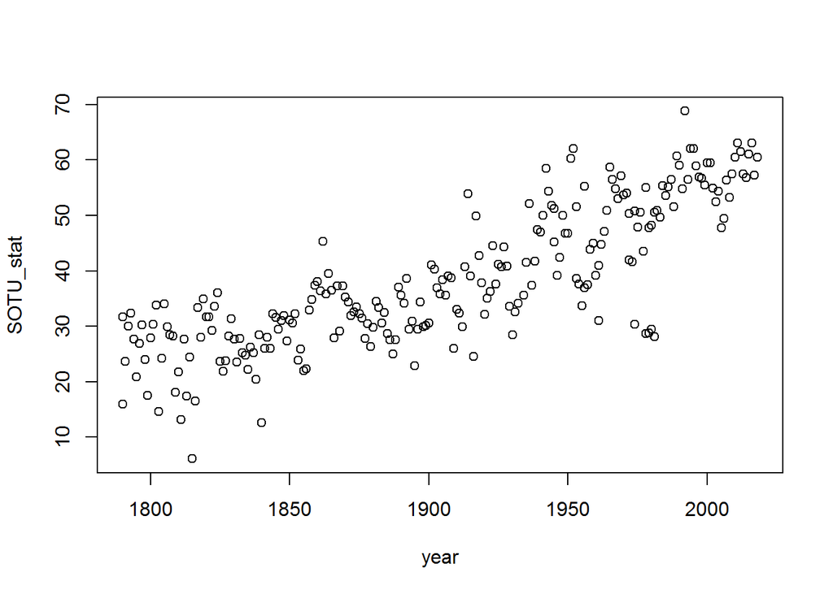

```r
# readability
measure <- "Flesch"

SOTU_stat <- textstat_readability(data_corpus_SOTU, measure)

SOTU_year <- lubridate::year(docvars(data_corpus_SOTU, "Date"))
SOTU_df <- data.frame("year" = SOTU_year, "SOTU_stat" = SOTU_stat$Flesch)
plot(SOTU_df)
```

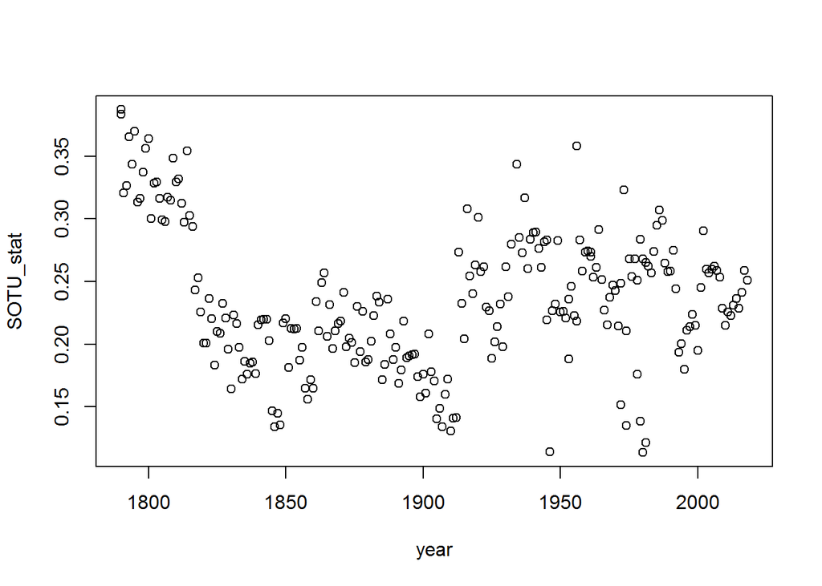

```r
# lexical diversity -- Type to Token ratio
SOTU_stat <- textstat_lexdiv(dfm(data_corpus_SOTU) )

SOTU_year <- lubridate::year(docvars(data_corpus_SOTU, "Date"))
SOTU_df <- data.frame("year" = SOTU_year, "SOTU_stat" = SOTU_stat$TTR)
plot(SOTU_df)
```

### Identifying most unique features of documents

One approach is to use *TF-IDF* weights instead of just token counts in the DFM:

```r
rew <- dfm_tfidf(dfm(data_corpus_SOTU))
# now most frequent features are different
topfeatures(dfm(data_corpus_SOTU))
```

```
##    the     of      ,      .     to    and     in      a   that    for
## 165187 106261  93066  70583  67695  67626  43178  31072  23959  21579
```

```r
topfeatures(rew)
```

```
##         -         •   program  programs   tonight      upon         $
## 1208.9276  528.0814  389.0484  376.6422  366.9428  345.2390  332.4178
##  economic      help    mexico
##  325.5435  304.3599  301.8972
```

### Clustering documents and features

We can identify documents that are similar to one another based on the frequency of words, using `similarity`. There’s different metrics to compute similarity. Here we explore two of them: [Jaccard distance](https://en.wikipedia.org/wiki/Jaccard_index) and [Cosine distance](https://en.wikipedia.org/wiki/Cosine_similarity).

```r
# document similarities
dfm_sotu<-dfm(data_corpus_SOTU)


simils <- textstat_simil(dfm_sotu, "Trump-2018", margin="documents", method="jaccard")


# most similar documents
df <- data.frame(
  docname = rownames(simils),
  simil = as.numeric(simils),
  stringsAsFactors=F
)
tail(df[order(simils),])
```

```
##          docname     simil
## 231   Obama-2010 0.2756290
## 215 Clinton-1994 0.2766120
## 217 Clinton-1996 0.2776660
## 233   Obama-2012 0.2799407
## 238   Trump-2017 0.2989309
## 239   Trump-2018 1.0000000
```

```r
head(df[order(simils),])
```

```
##             docname      simil
## 1   Washington-1790 0.09499489
## 2  Washington-1790b 0.10742188
## 12       Adams-1800 0.10813492
## 11       Adams-1799 0.10888672
## 4   Washington-1792 0.11075661
## 3   Washington-1791 0.11290323
```

```r
# another example
simils <- textstat_simil(dfm_sotu, "Obama-2012", margin="documents", method="jaccard")
# most similar documents
df <- data.frame(
  docname = rownames(simils),
  simil = as.numeric(simils),
  stringsAsFactors=F
)
tail(df[order(simils),])
```

```
##        docname     simil
## 236 Obama-2015 0.3239651
## 235 Obama-2014 0.3301043
## 234 Obama-2013 0.3452150
## 231 Obama-2010 0.3461538
## 232 Obama-2011 0.3564202
## 233 Obama-2012 1.0000000
```

```r
head(df[order(simils),])
```

```
##             docname      simil
## 1   Washington-1790 0.09450767
## 12       Adams-1800 0.10090866
## 11       Adams-1799 0.10538752
## 7   Washington-1795 0.11086957
## 2  Washington-1790b 0.11132255
## 21     Madison-1809 0.11364674
```

And the opposite: term similarity based on the frequency with which they appear in documents:

```r
# term similarities
simils <- textstat_simil(dfm_sotu, "unemployment", margin="features", method="cosine")
# most similar features
df <- data.frame(
  featname = rownames(simils),
  simil = as.numeric(simils),
  stringsAsFactors=F
)
head(df[order(simils, decreasing=TRUE),], n=10)
```

```
##           featname     simil
## 24152 unemployment 1.0000000
## 14398     economic 0.8188231
## 22325      program 0.8078425
## 1413    employment 0.8041370
## 24291       levels 0.8013408
## 9993     inflation 0.8005202
## 16939      housing 0.7999228
## 729        federal 0.7936173
## 20240      billion 0.7918210
## 3792         level 0.7831139
```

```r
# another example...
simils <- textstat_simil(dfm_sotu, "america", margin="features", method="cosine")
# most similar features
df <- data.frame(
  featname = rownames(simils),
  simil = as.numeric(simils),
  stringsAsFactors=F
)
head(df[order(simils, decreasing=TRUE),], n=10)
```

```
##        featname     simil
## 3222    america 1.0000000
## 3939  americans 0.8267723
## 27850   tonight 0.7902963
## 1190   together 0.7514774
## 488          us 0.7455618
## 19251 america's 0.7430479
## 8573    chamber 0.7397545
## 20043   speaker 0.7340172
## 20          you 0.7334641
## 345        know 0.7255908
```

Each of these can then be used to cluster documents:

```r
recent <- dfm_sotu[190:239,]
# compute distances
distances <- textstat_dist(recent, margin="documents")
as.matrix(distances)[1:5, 1:5]
```

```
##             Nixon-1974 Nixon-1974b Ford-1975 Ford-1976 Ford-1977
## Nixon-1974      0.0000    1982.779  229.1004  206.7777  158.5150
## Nixon-1974b  1982.7786       0.000 2126.4510 2053.4284 2023.3121
## Ford-1975     229.1004    2126.451    0.0000  153.1927  169.7233
## Ford-1976     206.7777    2053.428  153.1927    0.0000  157.0096
## Ford-1977     158.5150    2023.312  169.7233  157.0096    0.0000
```

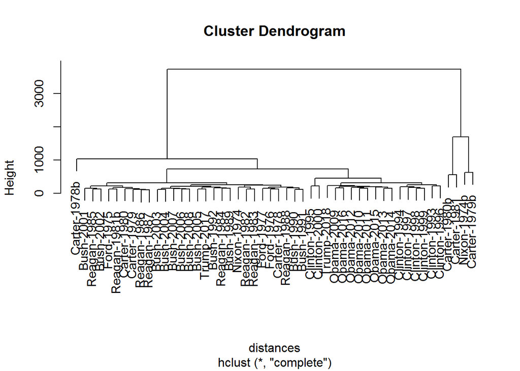

```r
# clustering
cluster <- hclust(distances)
plot(cluster)
```

A different type of clustering is [principal component analysis](https://en.wikipedia.org/wiki/Principal_component_analysis). This technique will try to identify a set of uncorrelated variables that capture most of the variance in the document-feature matrix. The first component will always capture the largest proportion of the variance; the second captures the second largest, etc. Looking at the relative proportion of the variance captured by the first component vs the rest, we can see to what extent we can reduce the dataset to just one dimension.

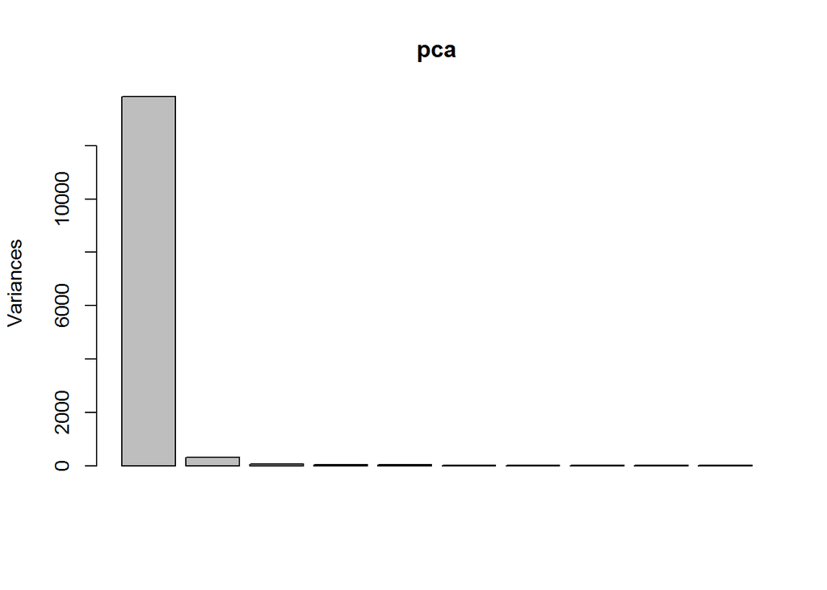

```r
# Principal components analysis
pca <- prcomp(t(as.matrix(dfm_sotu)))
plot(pca) # first PC captures most of the variance
```

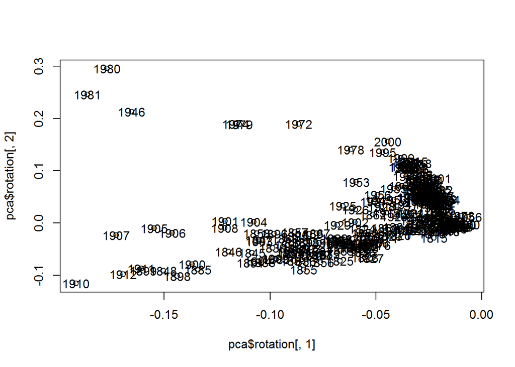

```r
# plot first principal component
plot(pca$rotation[,1], pca$rotation[,2])
text(pca$rotation[,1], pca$rotation[,2], labels=lubridate::year(docvars(data_corpus_SOTU, "Date")))
```

```r
# looking at features for each PC
df <- data.frame(
  featname = featnames(dfm_sotu),
  dim1 = pca$x[,1],
  dim2 = pca$x[,2],
  stringsAsFactors=FALSE
)

head(df[order(df$dim1),])
```

```
##     featname       dim1       dim2
## the      the -13771.912 -1207.0365
## of        of  -8733.145 -1076.7407
## ,          ,  -7241.773   459.7470
## .          .  -5342.177  1833.8332
## and      and  -5337.633   722.3756
## to        to  -5326.935   639.0712
```

```r
tail(df[order(df$dim1),])
```

```
##                      featname     dim1       dim2
## misemployed       misemployed 5.132908 -0.5656977
## residuary           residuary 5.132908 -0.5656977
## intimating         intimating 5.134738 -0.5648409
## licentiousness licentiousness 5.134738 -0.5648409
## beguiled             beguiled 5.135535 -0.5505397
## re-insurance     re-insurance 5.135535 -0.5505397
```

```r
head(df[order(df$dim2),])
```

```
##       featname       dim1       dim2
## the        the -13771.912 -1207.0365
## of          of  -8733.145 -1076.7407
## which    which  -1098.537  -209.8881
## by          by  -1361.619  -190.1762
## be          be  -1675.433  -159.2236
## upon      upon   -366.601  -145.4215
```

```r
tail(df[order(df$dim2),])
```

```
##     featname       dim1      dim2
## ,          , -7241.7733  459.7470
## to        to -5326.9349  639.0712
## our      our -1288.8939  671.7119
## and      and -5337.6334  722.3756
## we        we  -786.0777  936.6944
## .          . -5342.1772 1833.8332
```

A similar dimensionality reduction technique is [correspondence analysis](https://en.wikipedia.org/wiki/Correspondence_analysis).

```r
out <- textmodel_ca(dfm_sotu)

# documents
df <- data.frame(
  docname = docnames(dfm_sotu),
  year = lubridate::year(docvars(data_corpus_SOTU, "Date")),
  dim1 = out$rowcoord[,1],
  dim2 = out$rowcoord[,2],
  stringsAsFactors=FALSE
)

head(df[order(df$dim1),])
```

```
##                   docname year       dim1        dim2
## Monroe-1820   Monroe-1820 1820 -1.0180071 -0.31581903
## Monroe-1821   Monroe-1821 1821 -1.0180071 -0.31581903
## Adams-1827     Adams-1827 1827 -1.0058869 -0.20225199
## Monroe-1819   Monroe-1819 1819 -0.9573476 -0.36635489
## Madison-1810 Madison-1810 1810 -0.9428731 -0.08298681
## Polk-1846       Polk-1846 1846 -0.9229782 -0.45407532
```

```r
tail(df[order(df$dim1),])
```

```
##                   docname year     dim1      dim2
## Obama-2012     Obama-2012 2012 2.038419 -2.363692
## Obama-2016     Obama-2016 2016 2.106665 -3.023273
## Clinton-2000 Clinton-2000 2000 2.132552 -2.103390
## Obama-2013     Obama-2013 2013 2.160693 -2.174854
## Obama-2015     Obama-2015 2015 2.232701 -2.992493
## Obama-2014     Obama-2014 2014 2.246677 -2.625231
```

```r
head(df[order(df$dim2),])
```

```
##               docname year     dim1      dim2
## Obama-2016 Obama-2016 2016 2.106665 -3.023273
## Obama-2015 Obama-2015 2015 2.232701 -2.992493
## Trump-2018 Trump-2018 2018 1.834059 -2.702649
## Obama-2014 Obama-2014 2014 2.246677 -2.625231
## Obama-2011 Obama-2011 2011 2.025172 -2.373139
## Obama-2012 Obama-2012 2012 2.038419 -2.363692
```

```r
tail(df[order(df$dim2),])
```

```
##                         docname year     dim1     dim2
## Nixon-1974b         Nixon-1974b 1974 1.303479 1.883780
## Eisenhower-1961 Eisenhower-1961 1961 1.145222 1.902622
## Carter-1979b       Carter-1979b 1979 1.444418 2.673602
## Carter-1978b       Carter-1978b 1978 1.568092 2.747097
## Carter-1980b       Carter-1980b 1980 1.425784 2.915334
## Carter-1981         Carter-1981 1981 1.378134 2.958999
```

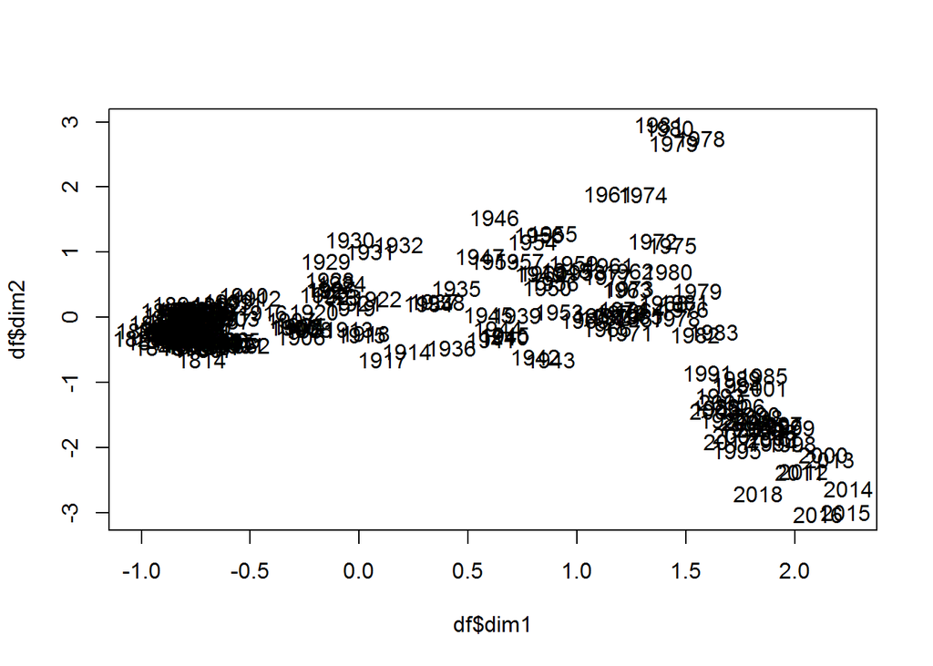

```r
plot(df$dim1, df$dim2, type="n")
text(df$dim1, df$dim2, labels=df$year)
```

```r
# features
df <- data.frame(
  featname = featnames(dfm_sotu),
  dim1 = out$colcoord[,1],
  dim2 = out$colcoord[,2],
  stringsAsFactors=FALSE
)

head(df[order(df$dim1),])
```

```
##                    featname      dim1      dim2
## countervailed countervailed -2.315588 -1.034349
## re-shipped       re-shipped -2.315588 -1.034349
## comported         comported -2.315588 -1.034349
## dismission       dismission -2.315588 -1.034349
## 5.59                   5.59 -2.315588 -1.034349
## 4,735,296.30   4,735,296.30 -2.315588 -1.034349
```

```r
tail(df[order(df$dim1),])
```

```
##          featname     dim1      dim2
## she'd       she'd 5.110357 -8.597974
## nick         nick 5.110357 -8.597974
## john's     john's 5.110357 -8.597974
## 10.10       10.10 5.110357 -8.597974
## myra         myra 5.110357 -8.597974
## remsburg remsburg 5.110357 -8.597974
```

```r
head(df[order(df$dim2),])
```

```
##                    featname    dim1      dim2
## antsy                 antsy 4.79188 -9.901614
## tips                   tips 4.79188 -9.901614
## personalizing personalizing 4.79188 -9.901614
## slam                   slam 4.79188 -9.901614
## a-where             a-where 4.79188 -9.901614
## nation-our       nation-our 4.79188 -9.901614
```

```r
tail(df[order(df$dim2),])
```

```
##                featname     dim1     dim2
## spectre         spectre 3.134744 9.691109
## radioactive radioactive 3.134744 9.691109
## wic                 wic 3.134744 9.691109
## cds                 cds 3.134744 9.691109
## hhs                 hhs 3.134744 9.691109
## iran-iraq     iran-iraq 3.134744 9.691109
```